# Séance 3 : Analyse de réseaux avec R

## Projection

On utilise la fonction **bipartite_projection** fournie dans **igraph** pour créer deux projections à partir du réseau bipartite étudiant-université :

- d’une part, un réseau d’étudiants liés par les universités qu’ils ont en commun ;
- d’autre part, un réseau d’universités liées par les étudiants qu’elles partagent.

```r
proj <- bipartite_projection(g2)

g_univ <- proj$proj1  # réseau des universités
g_etud <- proj$proj2  # réseau des étudiants
```

Visualisons les projections obtenues :

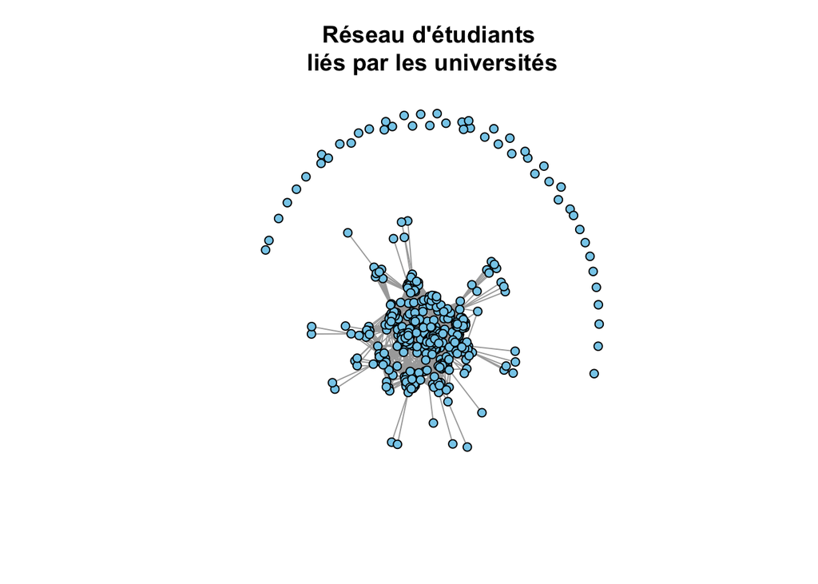

```r
plot(g_etud, vertex.color = "skyblue",
     vertex.size = 5,
     vertex.label = NA,
     layout = layout_with_fr,
     main = "Réseau d'étudiants \nliés par les universités")
```

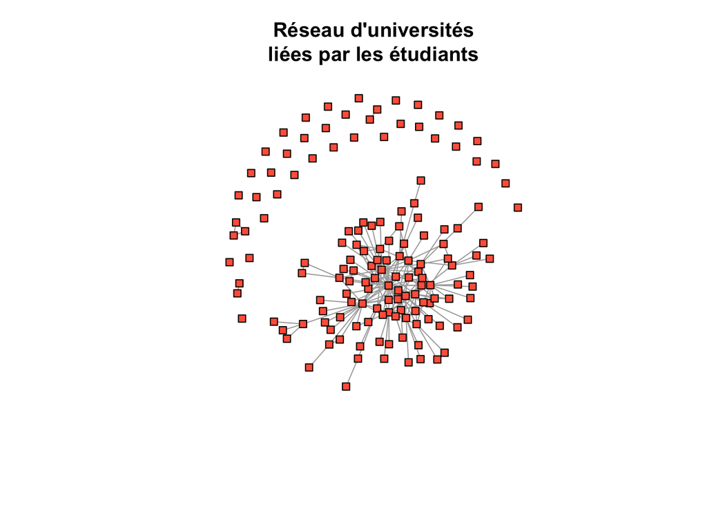

```r
plot(g_univ, vertex.color = "tomato",
     vertex.shape = "square",
     vertex.size = 5,
     vertex.label = NA,
     layout = layout_with_fr,
     main = "Réseau d'universités\nliées par les étudiants")
```

On peut ensuite appliquer à chaque projection les mesures classiques développées pour les réseaux simples (voir la première partie.)

**⚠️ Attention**: la projection introduit des biais dus à la densification artificielle du graphe.

## Packages spécifiques

### bipartite

Le package **bipartite** est spécialisé dans les réseaux écologiques mais applicable à d’autres domaines. Il fournit des mesures spécifiques et des visualisations aux réseaux bipartites, ainsi que des projections pondérées.

```r
library(bipartite)

# Convertir ton graphe en matrice incidence (étudiants en lignes, universités en colonnes)
inc_mat <- as_incidence_matrix(g2, types = V(g2)$type)

# Calculer la connectance (densité bipartite)
networklevel(inc_mat, index = "connectance")

# Visualiser le réseau bipartite en matrice
plotweb(inc_mat, method = "normal", text.rot = 90)
```

### tnet

Le package **tnet** permet une analyse fine des réseaux bipartites pondérés et propose des mesures comme le degré redondant ou la centralité bipartite.

```r
library(tnet)

# Conversion de la matrice incidence en format long
# Format attendu : data.frame avec colonnes : étudiant, université, poids
edges <- as_data_frame(g2, what = "edges")

# Exemple 1 : calcul du degré redondant

tnet_data <- as.tnet(edges, type = "two-mode")
bip_deg <- degree_tm(tnet_data)
head(bip_deg)
```

La fonction **degree_tm()** retourne un tableau avec les colonnes suivantes :

- node : le nom du nœud (étudiant ou une université).
- degree : le nombre de liens du nœud vers des nœuds de l’autre type : pour un étudiant, le nombre d’universités auxquelles il est lié ; pour une université, le nombre d’étudiants qui y sont affiliés.

```r
# Exemple 2 : calcul de centralité bipartite

tnet_data2 <- as.tnet(edges, type = "weighted two-mode tnet")
bip_centrality <- degree_wtm(tnet_data2)
head(bip_centrality)
```

La fonction **degree_wtm()** retourne un tableau avec les colonnes suivantes :

- degree : nombre de connexions du nœud (non pondéré).
- norm.degree : degré normalisé.
- strength : somme des poids (1 si non pondéré).
- norm.strength : force normalisée.

## A retenir

Les outils classiques d’analyse de réseaux doivent être appliqués de manière critique aux réseaux bipartites :

- Les mesures standard peuvent être trompeuses dans un réseau bipartite ;
- La projection sur un sous-ensemble (personnes ou événements) permet l’application de métriques classiques, mais au prix d’une simplification et d’une perte d’information (concernant notamment la nature des liens) ;
- L’analyse rigoureuse de réseaux bipartites requiert des métriques adaptées ou des algorithmes spécifiques.
- La méthode fondée sur la recherche d’équivalences structurales ou régulières permet de rectifier certains biais des outils classiques.